# Study on Flu Seasons

4/25/2019

## Introduction to the Problem: Influenza Prediction

**How to predict the intensity of the 2018-2019 Influenza season?**

Why we are interested:

- There were ~80,000 flu-related deaths in 2017-18. This year's flu season has been 'record-breaking in duration' (CDC).
- Knowing how to predict -> effective and timely precautionary measures.

## Introduction to the Problem: Influenza Prediction

We want to estimate the following outcomes of flu **intensity**:

- Mortality (number of flu-related deaths)
- Flu Visits (number of visits to health care providers for flu)
- Flu Tests (number of positive tests on major flu types)

Using these predictors:

- Region (National level, State level)
- Age Groups (Infants, Juniors, Seniors)
- Vaccination Data

## Description of Data

```
##    YEAR WEEK AGE.0.4 AGE.5.24 AGE.25.49 AGE.50.64 AGE.65 ILITOTAL
## 1: 2010   40    2627     3142      1677       627    400     8473
## 2: 2010   41    2953     3522      1779       649    444     9347
## 3: 2010   42    3044     3641      1898       690    411     9684
## 4: 2010   43    3226     3822      1754       682    420     9904
## 5: 2010   44    3451     4397      1981       736    455    11020
## 6: 2010   45    3927     4679      1956       734    511    11807
```

- Flu data often undereported due to identification/reporting delays

## ILI Visits Overview

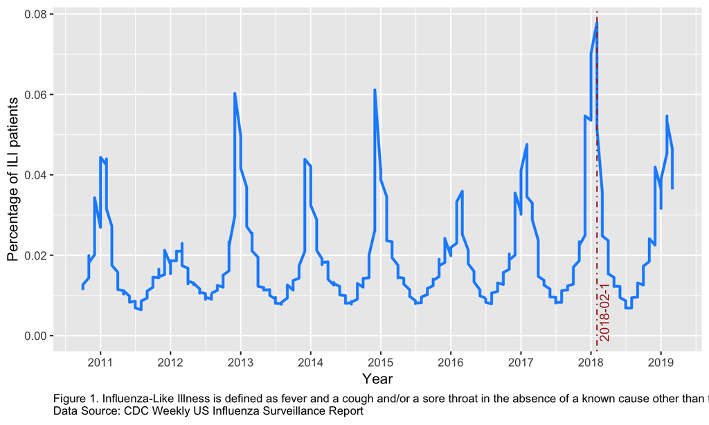

What happened in 2018?

## ILI visits by Age group, 2018

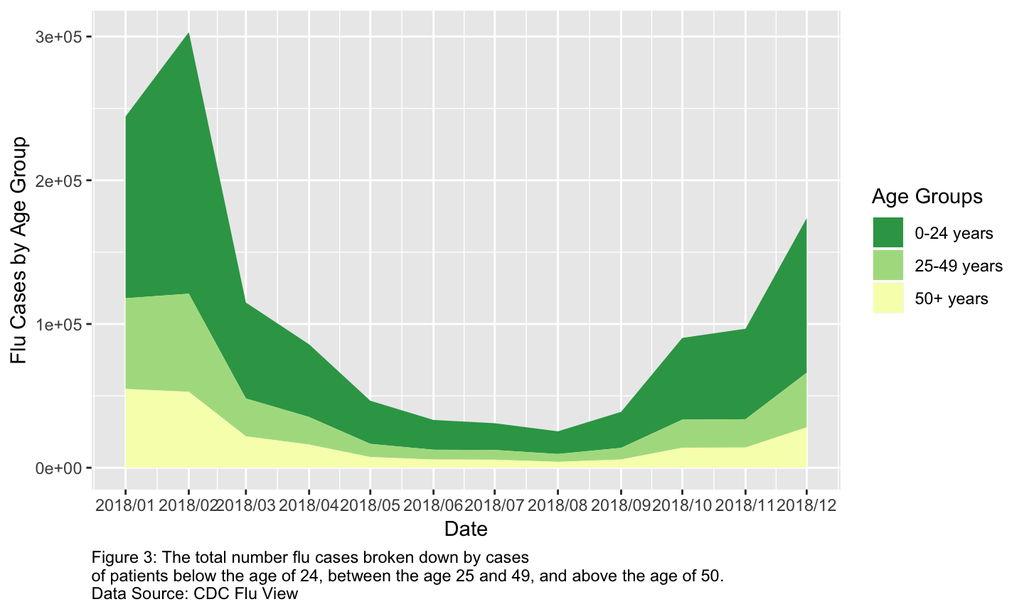

## Flu vaccines vs. visits

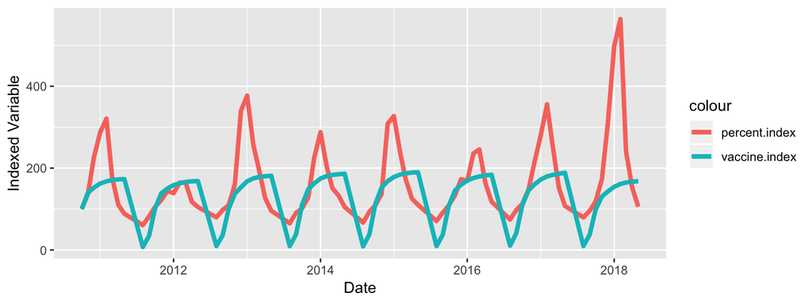

- Seasonality
- Lagged effects
- Flu vaccines consistent, flu diagnoses volatile

## Analysis: Statistical Methods

- Model: time series model *SARIMA*
- Reason: The datasets we have are basically time series data. The most widely used model in time series predicting is *SARIMA* models.
- Task: Selecting seasonal, differencing, autoregressive, and moving average parameters.
- Methodology: Looking at ACF/PACF lags and AICC criteria.

## Implementation: Fitting model

```r
m.auto <- auto.arima(series, max.p=3)
m.auto
```

```
## Series: series
## ARIMA(3,0,2)(0,1,1)[52]
##
## Coefficients:
##          ar1     ar2      ar3     ma1     ma2     sma1
##       0.8532  0.6584  -0.6274  0.4758  -0.397  -0.4516
## s.e.  0.1586  0.2284   0.1054  0.1570   0.081   0.0563
##
## sigma^2 estimated as 0.05387:  log likelihood=11.87
## AIC=-9.74   AICc=-9.44   BIC=18.03
```

## Implementation: Forecasting

```r
pred.list <- forecast(m.auto, h = 52) #point forecasts and CIs
predictions <- pred.list$mean
```

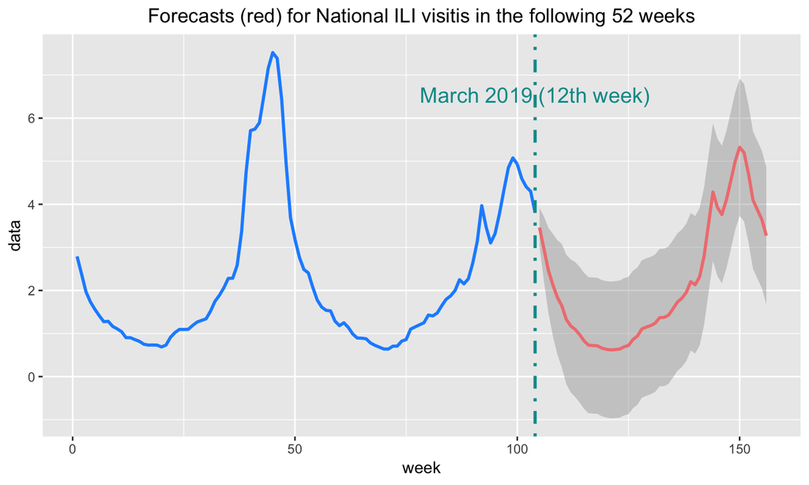

## Shiny Apps

[figure not shown]

## Limitations and Uncertainties

- Data: not random, underreporting, patterns may change over time, size too small
- Difficult to make time series predictions, especially on flu incidence. May not be able to predict any flu outbreak in the future
- Could be other models such as machine learning models that may outperform the time series model